# Naturindeks for fjell

# Analyser av Naturindeks for fjell

Først så prøver jeg å gjenskape fjellindeksen slik den er på nettsiden. Indeksen skal være 0.56.

# Importerer data fra NI - ImportDatasetAPI

Fyll inn ditt eget passord og brukernavn

```r
myUser <- "anders.kolstad@nina.no"
myPwd  <- "" # hemmelig passord
```

Importerer data fra NI-databasen og lagrer datasettet på server

```r
fjelldat <- NIcalc::importDatasetApi(
  username = myUser,
  password = myPwd,
  eco = "Fjell",
  indic = NULL,
  year = c("1990","2000","2010","2014","2019"))

saveRDS(fjelldat, "/data/P-Prosjekter/41201042_okologisk_tilstand_fastlandsnorge_2020_dataanaly/fjell2021/data/naturindeks/NIfjell-1990-2019.rds")

rm(fjelldat)
rm(myPwd)
```

Laster tilbake datasettet:

```r
fjelldat <- readRDS("/data/P-Prosjekter/41201042_okologisk_tilstand_fastlandsnorge_2020_dataanaly/fjell2021/data/naturindeks/NIfjell-1990-2019.rds")
```

Liste over arter som inngår

```r
fjelldat$indicators$name
```

```
##  [1] "Heilo"                       "Boltit"
##  [3] "Snøspurv"                    "Steinskvett"
##  [5] "Heipiplerke"                 "Fjellerke"
##  [7] "Ravn"                        "Blåstrupe"
##  [9] "Ringtrost"                   "Lappspurv"
## [11] "Fjellrype"                   "Villrein"
## [13] "Lirype"                      "smågnagere - fjellbestander"
## [15] "Tamrein"                     "Vier alpint belte"
## [17] "Fjellfiltmose"               "Issoleie"
## [19] "Praktdraugmose"              "Fjellvalmue"
## [21] "Greplyng"                    "Nipdraugmose"
## [23] "Lavhei"                      "Sylmose"
## [25] "Torntvebladmose"             "Fjellvåk"
## [27] "Jerv"                        "Kongeørn"
## [29] "Jaktfalk"                    "Fjellrev"
```

Her er det bare arter eller artsgrupper som ingår som indikatorer. Det er bra.

# Strukturerer datasettet - assembleNiObject

Specify whole land area of Norway and all five country parts as Niunits:

```r
myNIunits <- c(allArea = T, parts = T, counties = F)
```

Only include Bsunits (kommuner) where the mountain ecosystem covers more than x% of the terrestrial area.

```r
myPartOfTotal <- .2
```

```r
fjell_assemeble <- NIcalc::assembleNiObject(
  inputData = fjelldat,
  predefNIunits = myNIunits,
  partOfTotal = myPartOfTotal,
  indexType = "ecosystem",
  part = "ecosystem",
  total = "terrestrial")

saveRDS(fjell_assemeble, "/data/P-Prosjekter/41201042_okologisk_tilstand_fastlandsnorge_2020_dataanaly/fjell2021/data/naturindeks/NIfjellAssemble.rds")

rm(fjell_assemeble)
```

Henter tilbake datasettet

```r
fjell_assemeble <- readRDS("/data/P-Prosjekter/41201042_okologisk_tilstand_fastlandsnorge_2020_dataanaly/fjell2021/data/naturindeks/NIfjellAssemble.rds")
```

## Reduce the number of functional groups

Reduce the number of functional groups in the data set in order to avoid unintentionally emphasizing single non-key indicators. I.e. merge generalists and specialists into one group for each trophic level.

```r
xxx <- yyy <- fjell_assemeble$indicators$functionalGroup
xxxId <- yyyId <- fjell_assemeble$indicators$functionalGroupId
yyy[xxxId %in% c(1,2)] <- "Mellompredator"
yyyId[xxxId %in% c(1,2)] <- 1
yyy[xxxId %in% c(6,7)] <- "Primærprodusent"
yyyId[xxxId %in% c(6,7)] <- 6
yyy[xxxId %in% c(8,9)] <- "Topp-predator"
yyyId[xxxId %in% c(8,9)] <- 8
fjell_assemeble$indicators$functionalGroup <- yyy
fjell_assemeble$indicators$functionalGroupId <- yyyId
```

## Imputations for missing values

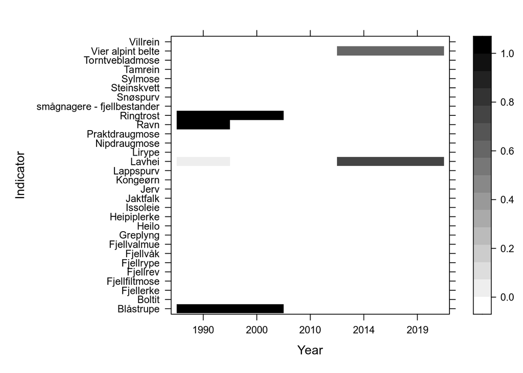

Figuren viser hvor det mangler data

```r
mountainDiagnostics <- NIcalc::imputeDiagnostics(x = fjell_assemeble,
nSim = 10,
transConst = 0.01,
maxit = 20)
mountainDiagnostics$diagnostics$mdDistribuiton
```

Det er noen datahull hvor vi imputerer data. Denne operasjonen tar en del tid, så jeg lagrer outputen på server og henter den tilbake (så slipper jeg å kjøre funksjonen på nytt hver gang).

```r
fjell_imputes <- NIcalc::imputeData(x = fjell_assemeble,
    nSim = 1000,
    transConst = 0.01,
    maxit = 20,
    printFlag = TRUE)

saveRDS(fjell_imputes, "/data/P-Prosjekter/41201042_okologisk_tilstand_fastlandsnorge_2020_dataanaly/fjell2021/data/naturindeks/NIfjell-imputes.rds")
```

Henter tilbake datasettet

```r
fjell_imputes <- readRDS("/data/P-Prosjekter/41201042_okologisk_tilstand_fastlandsnorge_2020_dataanaly/fjell2021/data/naturindeks/NIfjell-imputes.rds")
```

```r
mountainImputesCorr <- NIcalc::impStand(x = fjell_assemeble,
imputations = fjell_imputes)
```

# Regne ut fjellindeksen - calculateIndex  
Her regner jeg ut fjellindeksen tilsvarende den ‘offisielle’ versjonen

```r
fjellIndex <- NIcalc::calculateIndex(
  x       = fjell_assemeble,
  imputations = mountainImputesCorr,
  nsim     = 1000,
  awBSunit = "Fjell",
  fids     = F,    # should fidelities be ignored in
                   # the calculation of Wi?
  tgroups  = TRUE, # should grouping of indicators
                   # into trophic and key indicator
                   # groups be ignored
  keys     = "specialWeight", #"ignore",
  w        = 0.5
)
```

```r
summary(fjellIndex$wholeArea)
```

```
##                     2.5%    median     97.5% displacement
## wholeArea 1990 0.5823253 0.6247766 0.6570336  -0.03353905
## wholeArea 2000 0.5565617 0.5929846 0.6250013  -0.02763391
## wholeArea 2010 0.5637953 0.6047832 0.6389982  -0.01433097
## wholeArea 2014 0.5181795 0.5737360 0.6127493  -0.03708277
## wholeArea 2019 0.5052030 0.5632002 0.5968590  -0.03399622
```

Disse tallene stemmer med det som presenteres på nettsiden.

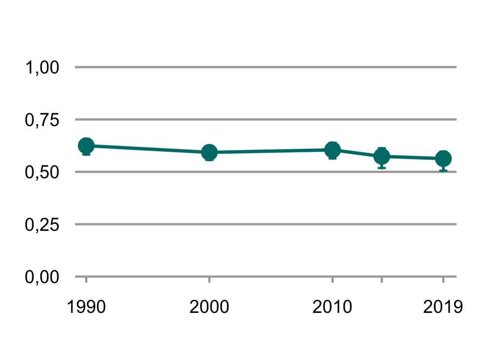

Naturindeksen for fjell

```r
plot(fjellIndex$wholeArea)
```

## Vekting

La oss se hvordan denne standardmetoden har vektlagt de ulike indikatorene

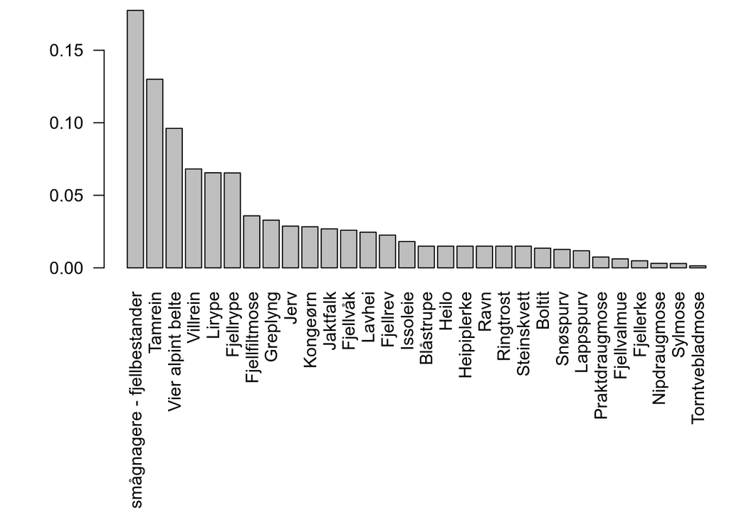

```r
wgt <- NIcalc::summaryWeights(fjellIndex$wholeArea)
wgt <- wgt[,ncol(wgt)]
wgt <- sort(wgt, decreasing = T)
par(mar=c(12,5,0.5,0))
barplot(wgt, las=2)
```

Fjellindeksen er i praksis oppgjort av kun rundt 6 indikatorer. Disse er trolig først og fremst de som har blit gitt ekstra vekt som nøkkelarter, og 5 av de 6 høyest vektede indikatorene er med i ØT-fjell som egne, separete indikatorer fra før.

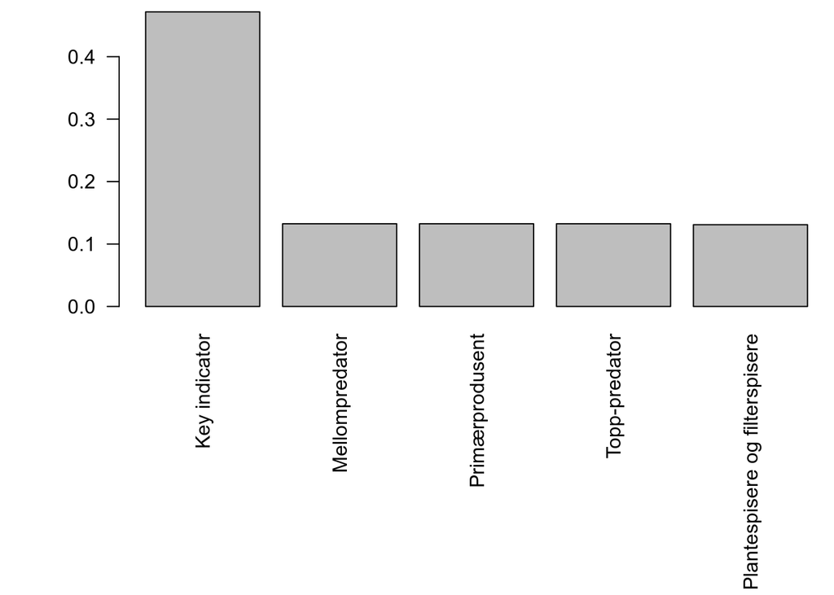

```r
wgtT <- NIcalc::summaryWeights(fjellIndex$wholeArea, group = "troph")
wgtT<- wgtT[,ncol(wgtT)]
wgtT <- sort(wgtT, decreasing = T)
par(mar=c(12,5,0.5,0))
barplot(wgtT, las=2)
```

Her ser vi igjen hvor viktige nøkkelartene er i utregningen av indeksen. Standardmetoden vekter også ned indikatorer som representerer trofiske grupper hvor det allerede finnes flere andre indikatorer (lik vekt til alle trofiske nivå). Indeksen er med andre ord designet for å gi et bilde av tilstanden på et gitt areal, og ikke tilstanden til artene som ingår som indikatorer.

# Index uten vekting av nøkkelarter trofiske grupper

```r
fjellIndex2 <- NIcalc::calculateIndex(
  x       = fjell_assemeble,
  imputations = mountainImputesCorr,
  nsim     = 1000,
  awBSunit = "Fjell",
  fids     = F,    # should fidelities be ignored in
                   # the calculation of Wi?
  tgroups  = F, # should grouping of indicators
                   # into trophic and key indicator
                   # groups be ignored
  keys     = "ignore",
  awbs=TRUE # arealvekting basert på fjellareal i hver kommune
)
```

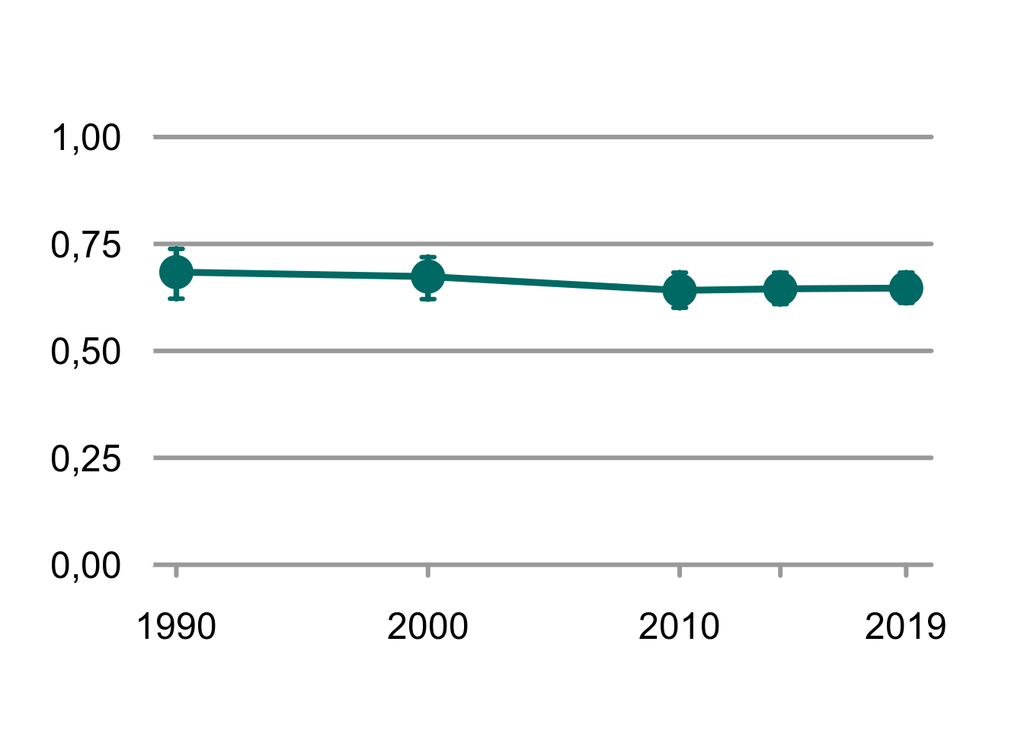

Figur over: Naturindeksen for fjell kalkulert uten spesiell vekting av nøkkelarter eller av funksjonelle grupper

```r
plot(fjellIndex2$wholeArea)
```

```r
summary(fjellIndex2$wholeArea)
```

```
##                     2.5%    median     97.5% displacement
## wholeArea 1990 0.6219559 0.6840825 0.7384633  -0.06132444
## wholeArea 2000 0.6209680 0.6737159 0.7192227  -0.05111930
## wholeArea 2010 0.6007775 0.6413486 0.6829586  -0.02868701
## wholeArea 2014 0.6094297 0.6450717 0.6828167  -0.02757541
## wholeArea 2019 0.6121504 0.6467650 0.6830266  -0.02533180
```

Indeksverdien blir en del høyere da: 0.65 istedet for 0.56. Her er verdiene for hele landet og for regionene.

```r
tbl <- as.data.frame(summary(fjellIndex2$wholeArea))[5,]
tbl2 <- as.data.frame(summary(fjellIndex2$E))[5,]
tbl3 <- as.data.frame(summary(fjellIndex2$S))[5,]
tbl4 <- as.data.frame(summary(fjellIndex2$W))[5,]
tbl5 <- as.data.frame(summary(fjellIndex2$C))[5,]
tbl6 <- as.data.frame(summary(fjellIndex2$N))[5,]

myTbl <- rbind(tbl,
               tbl2,
               tbl3,
               tbl4,
               tbl5,
               tbl6)
myTbl[,-4]
```

```
##                     2.5%    median     97.5%
## wholeArea 2019 0.6121504 0.6467650 0.6830266
## E 2019         0.5793758 0.6287124 0.6761452
## S 2019         0.5536736 0.6060681 0.6591850
## W 2019         0.5836366 0.6320401 0.6823710
## C 2019         0.6258619 0.6705520 0.7215638
## N 2019         0.6032052 0.6560668 0.7026271
```

## Vekting

La oss se hvordan denne custom-metoden har vektlagt de ulike indikatorene

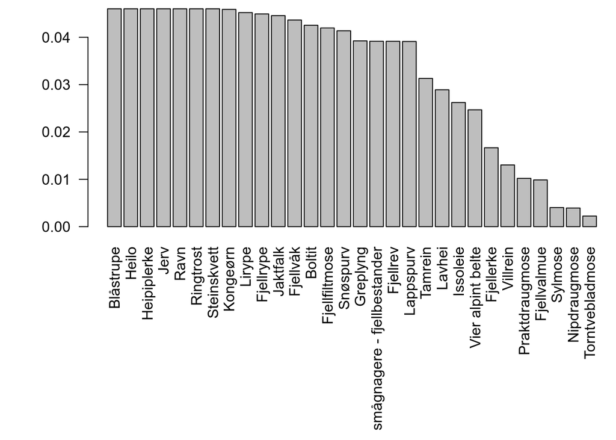

Figuren over: Vekting av indikatorer i fjellindeksen når det ikke gis spesiell vekt til nøkkelarter og det ikke tvinges fram en lik vekting for hvert trofiske nivå

```r
wgt2 <- NIcalc::summaryWeights(fjellIndex2$wholeArea)
wgt2 <- wgt2[,ncol(wgt2)]
wgt2 <- sort(wgt2, decreasing = T)
par(mar=c(12,5,0.5,0))
barplot(wgt2, las=2)
```

Nå var det mye mer jevnt. Ulikhetene nå skyldes to ting. 1) Ulik dekningsgrad - ikke alle indikatorene finnes eller har data fra alle BSunits (kommuner). Denne vektingen kan det nok være lurt å beholde. 2) arealvekting basert på fjellareal i hver kommune. Denne kan det også være lurt å beholde tror jeg, men jeg kan prøve å fjerne den bare for å se:

# Index uten awbs (area weight from basal units)

```r
fjellIndex3 <- NIcalc::calculateIndex(
  x       = fjell_assemeble,
  imputations = mountainImputesCorr,
  nsim     = 1000,
  awBSunit = "Fjell",
  fids     = F,    # should fidelities be ignored in
                   # the calculation of Wi?
  tgroups  = F, # should grouping of indicators
                   # into trophic and key indicator
                   # groups be ignored
  keys     = "ignore",
  awbs=FALSE
)
```

## Vekting

La oss se hvordan denne custom-metoden har vektlagt de ulike indikatorene

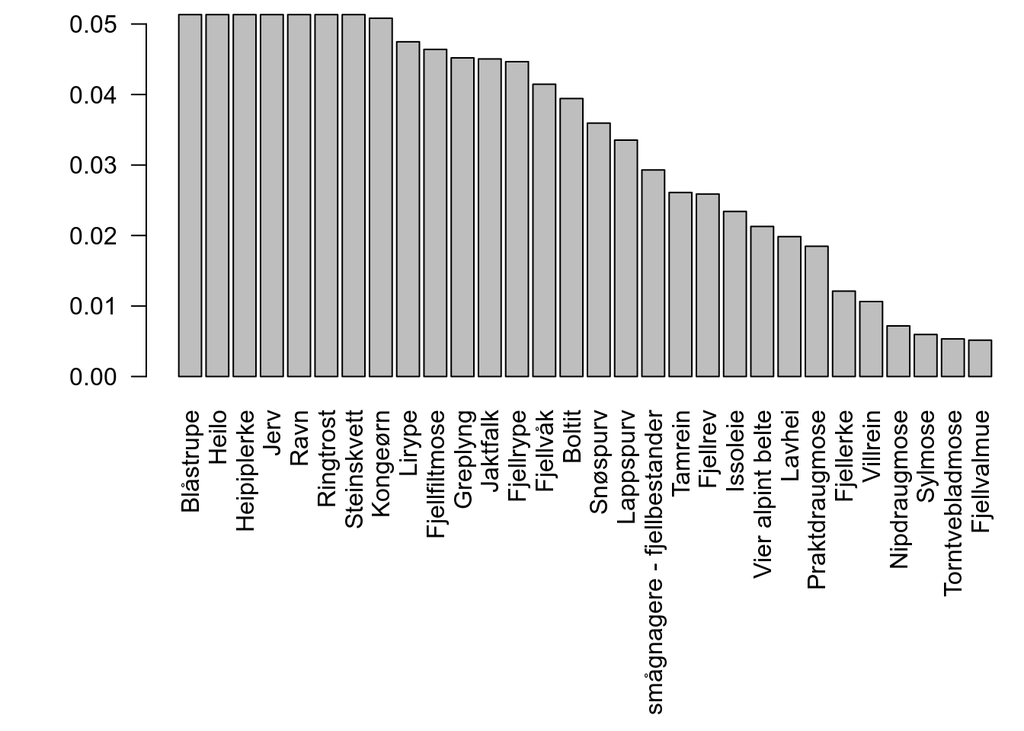

Figuren over: Vekting av indikatorer i fjellindeksen når alle kommuner (BSunits) teller likt uavhengig av totalareal eller fjellareal

```r
wgt3 <- NIcalc::summaryWeights(fjellIndex3$wholeArea)
wgt3 <- wgt3[,ncol(wgt3)]
wgt3 <- sort(wgt3, decreasing = T)
par(mar=c(12,5,0.5,0))
barplot(wgt3, las=2)
```

# Skaleringsnivå

En annen ting å tenke på er skaleringen og hvordan den forgår. Standardmetoden er slik at skaleringen foregår for hver ICunit basert på indikator verdien og referanseverdien for dette arealet. Vi ønsker kanskje egentlig at skaleringen skal foregå bare for hver region (NIunits: e,s,w,n,c), samt at for totalen så bør den bare være felles for hele landet. Dette ser ikke ut til å være en funskjon i NIcalc og krever at jeg gjør endringer i funksjonene, eller i datasettet med å summere opp referasneverdier og indikatorverdier for hver NIunit. Det er ikke så lett synbtes jeg.

Noen indikatorer har bare en referanseverdi som er felles for hele Norge, slik som blåstrupe

```r
fjelldat$referenceValues$referenceValues[fjelldat$referenceValues$referenceValues$indName=="Blåstrupe", c("indName", "ICunitName", "expectedValue")]
```

```
## # A tibble: 1 × 3
##   indName   ICunitName expectedValue
##   <chr>     <chr>              <dbl>
## 1 Blåstrupe Norge                100
```

Andre indikatorer har ulike referanseverdier for ulike arealenheter. Eksempelvis fjellrev:

```r
fjelldat$referenceValues$referenceValues[fjelldat$referenceValues$referenceValues$indName=="Fjellrev", c("indName", "ICunitName", "expectedValue")]
```

```
## # A tibble: 114 × 3
##    indName  ICunitName   expectedValue
##    <chr>    <chr>                <dbl>
##  1 Fjellrev Rendalen              14.8
##  2 Fjellrev Tolga                 14.8
##  3 Fjellrev Tynset                14.8
##  4 Fjellrev Alvdal                11.1
##  5 Fjellrev Os (Hedmark)          11.1
##  6 Fjellrev Folldal               25.9
##  7 Fjellrev Dovre                 37
##  8 Fjellrev Lesja                 70.3
##  9 Fjellrev Skjåk                 62.9
## 10 Fjellrev Lom                   59.2
## # … with 104 more rows
```

Vi ønsker at indikatorene og indeksen skal være indikatorfokusert og ikke areal-foksuert. Vi ønsker altså at man summerer (eller tar gjennomsnitt) av referanseverdien i alle ICunits i samme region og deler den summerte indikatorverdien på denne. For den skalerte indikatorverdien for hele landet bør man summere referanseverdien i absolutt alle ICunits og dele den summerte indikatorverdien på denne.